# ggbump

[figure not shown]

The R package `ggbump` creates elegant bump charts in ggplot. Bump charts are good to use to plot ranking over time.

## Installation

You can install ggbump from CRAN with:

```r
install.packages("ggbump")
```

Or the latest development version from [github](https://github.com/davidsjoberg/ggbump) with:

```r
devtools::install_github("davidsjoberg/ggbump")
```

## Bump chart Examples

Basic example:

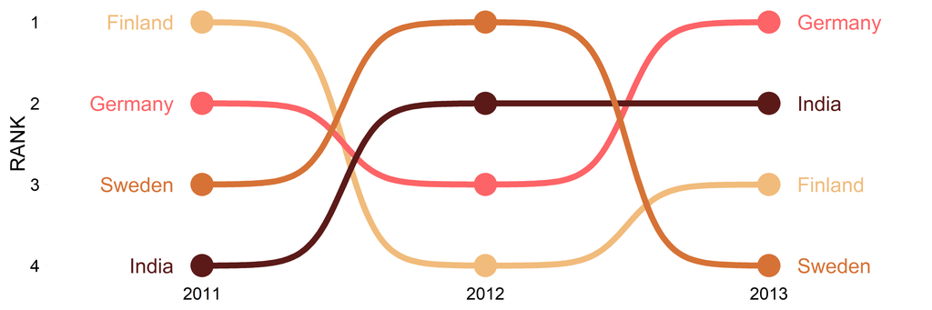

A more advanced example:

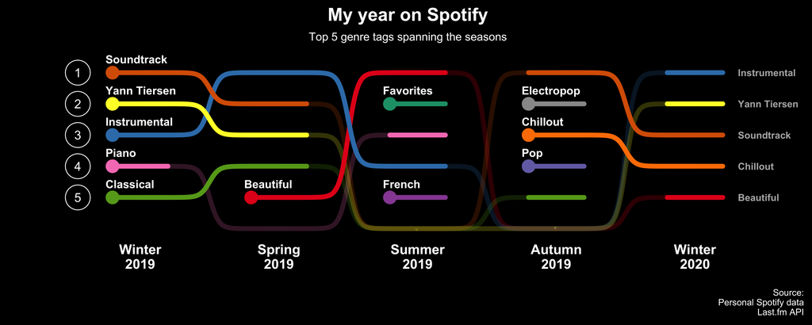

[Click here for code to the plot above](https://github.com/davidsjoberg/ggbump/wiki/My-year-on-Spotify)

Flags could be used instead of names:

[figure not shown]

[Click here for code to the plot above](https://github.com/davidsjoberg/ggbump/wiki/geom_bump-with-flags)

With `geom_sigmoid` you can make custom sigmoid curves:

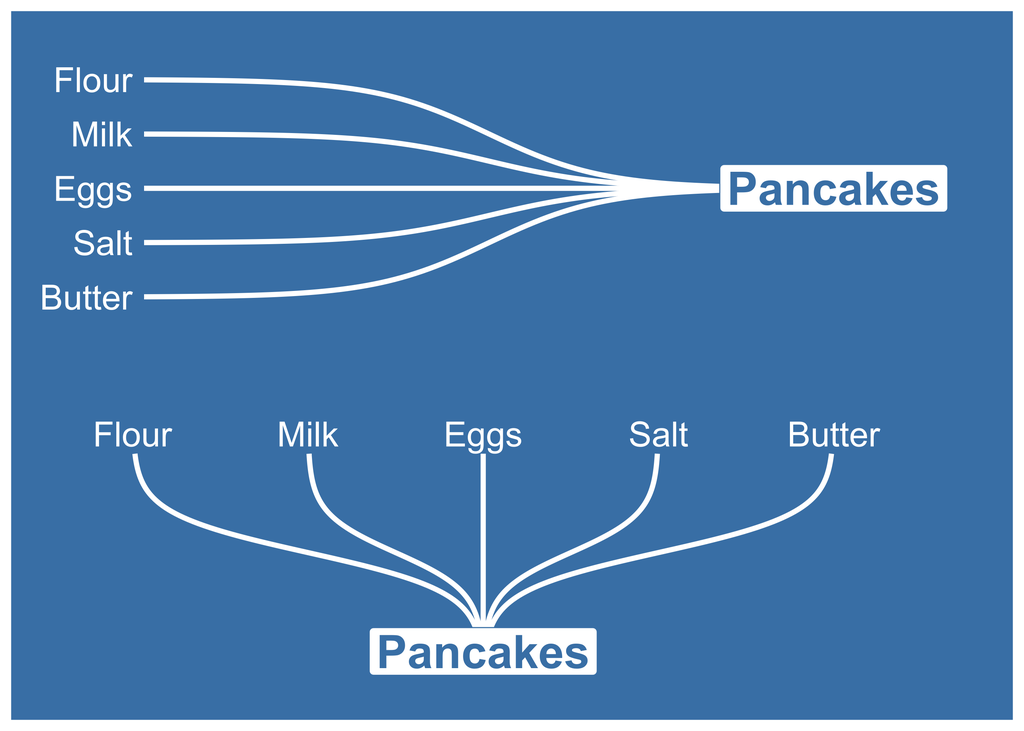

[Click here for code to the plot above](https://github.com/davidsjoberg/ggbump/wiki/geom_sigmoid)

# Tutorial

## Prep

Load packages and get some data with rank:

```r
if(!require(pacman)) install.packages("pacman")
library(ggbump)
pacman::p_load(tidyverse, cowplot, wesanderson)

df <- tibble(country = c("India", "India", "India", "Sweden", "Sweden", "Sweden", "Germany", "Germany", "Germany", "Finland", "Finland", "Finland"),
             year = c(2011, 2012, 2013, 2011, 2012, 2013, 2011, 2012, 2013, 2011, 2012, 2013),
             value = c(492, 246, 246, 369, 123, 492, 246, 369, 123, 123, 492, 369))

knitr::kable(head(df))
```

| country | year | value |
| --- | --- | --- |
| India | 2011 | 492 |
| India | 2012 | 246 |
| India | 2013 | 246 |
| Sweden | 2011 | 369 |
| Sweden | 2012 | 123 |
| Sweden | 2013 | 492 |

To create a ranking column we use `rank` from base R. We specify `ties.method = "random"` to make sure that each country have different rankings if they have the same value.

```r
df <- df %>%
  group_by(year) %>%
  mutate(rank = rank(value, ties.method = "random")) %>%
  ungroup()

knitr::kable(head(df))
```

| country | year | value | rank |
| --- | --- | --- | --- |
| India | 2011 | 492 | 4 |
| India | 2012 | 246 | 2 |
| India | 2013 | 246 | 2 |
| Sweden | 2011 | 369 | 3 |
| Sweden | 2012 | 123 | 1 |
| Sweden | 2013 | 492 | 4 |

## Make a bump chart

Most simple use case:

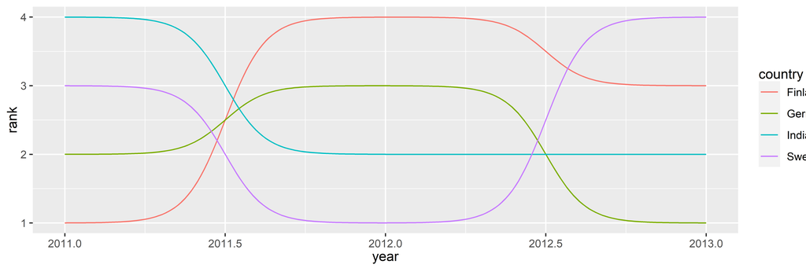

```r
ggplot(df, aes(year, rank, color = country)) +
    geom_bump()
```

## Pimp the bump chart!

Improve the bump chart by adding:

- A point for each rank observation.
- Choose a minimal theme, I use `theme_minimal_grid()` from `cowplot`.
- Choose nice colors so it does not look generic ggplot. I use a palette from `wesanderson`.
- Remove legend and add labels at the start and end of the bumpy ride.
- Reverse the y-axis to get rank 1 at the top.
- Adjust the ‘smoothness’ of the lines by setting `smooth` to 8. Higher means less smooth.

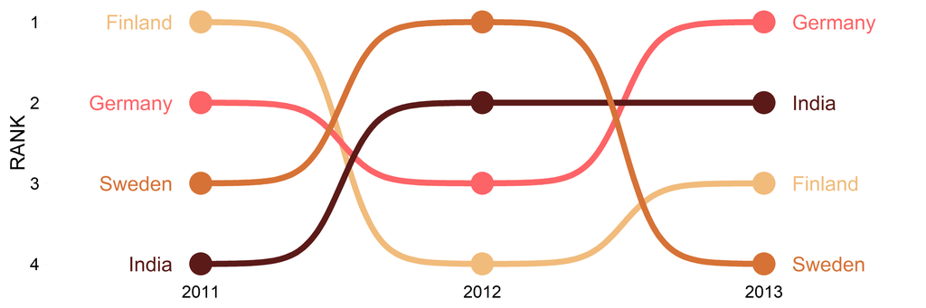

```r
ggplot(df, aes(year, rank, color = country)) +
  geom_point(size = 7) +
  geom_text(data = df %>% filter(year == min(year)),
            aes(x = year - .1, label = country), size = 5, hjust = 1) +
  geom_text(data = df %>% filter(year == max(year)),
            aes(x = year + .1, label = country), size = 5, hjust = 0) +
  geom_bump(size = 2, smooth = 8) +
  scale_x_continuous(limits = c(2010.6, 2013.4),
                     breaks = seq(2011, 2013, 1)) +
  theme_minimal_grid(font_size = 14, line_size = 0) +
  theme(legend.position = "none",
        panel.grid.major = element_blank()) +
  labs(y = "RANK",
       x = NULL) +
  scale_y_reverse() +
  scale_color_manual(values = wes_palette(n = 4, name = "GrandBudapest1"))
```

## geom_bump with factors

To use `geom_bump` with factors or character axis you need to prepare the data frame before. You need to prepare one column for the numeric position and one column with the name. If you want to have character/factor on both y and x you need to prepare 4 columns.

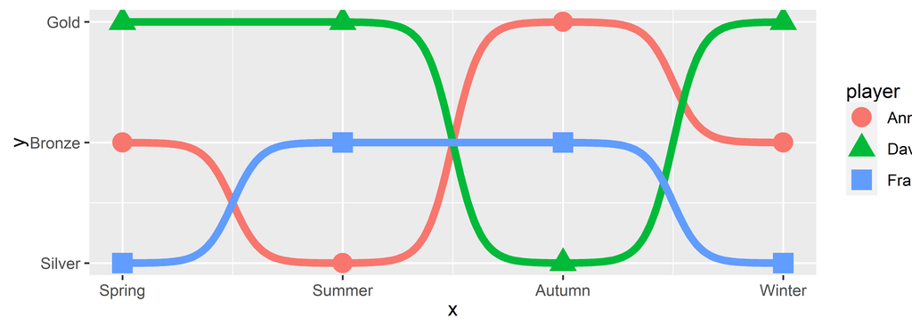

```r
# Original df
df <- tibble(season = c("Spring", "Summer", "Autumn", "Winter",
                        "Spring", "Summer", "Autumn", "Winter",
                        "Spring", "Summer", "Autumn", "Winter"),
             position = c("Gold", "Gold", "Bronze", "Gold",
                          "Silver", "Bronze", "Gold", "Silver",
                          "Bronze", "Silver", "Silver", "Bronze"),
             player = c(rep("David", 4),
                        rep("Anna", 4),
                        rep("Franz", 4)))

# Create factors and numeric columns
df <- df %>%
  mutate(season = factor(season,
                         levels = c("Spring", "Summer", "Autumn", "Winter")),
         x = as.numeric(season),
         position = factor(position,
                           levels = c("Gold", "Silver", "Bronze")),
         y = as.numeric(position))

# Add manual axis labels to plot
p <- ggplot(df, aes(x, y, color = player)) +
  geom_bump(size = 2, smooth = 8, show.legend = F) +
  geom_point(size = 5, aes(shape = player)) +
  scale_x_continuous(breaks = df$x %>% unique(),
                     labels = df$season %>% levels()) +
  scale_y_reverse(breaks = df$y %>% unique(),
                     labels = df$position %>% levels())
p
```

### And some nice theme features

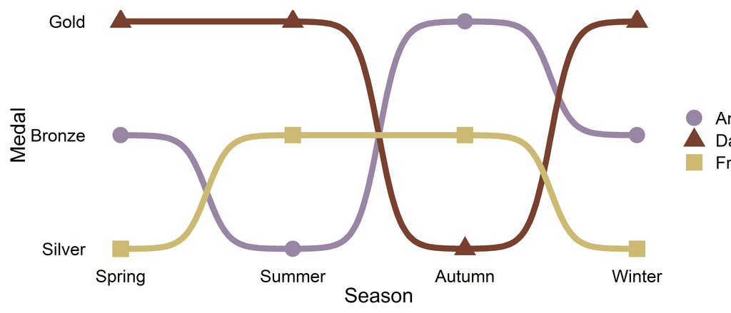

```r
p +
  theme_minimal_grid(font_size = 14, line_size = 0) +
  theme(panel.grid.major = element_blank(),
        axis.ticks = element_blank()) +
  labs(y = "Medal",
       x = "Season",
       color = NULL,
       shape = NULL) +
  scale_color_manual(values = wes_palette(n = 3, name = "IsleofDogs1"))
```

## Feedback

If you find any error or have suggestions for improvements you are more than welcome to contact me :)